# Phase 10 — Bootstrap Confidence Intervals

Empirical parameter uncertainty by subject resampling

Author

Pramod BR

Published

June 28, 2026

## 1 Objectives

The parameter CIs reported so far are **asymptotic** — derived from the covariance matrix under large-sample, normal assumptions. With only 12 subjects those assumptions are questionable. This phase computes **bootstrap** CIs that make no such assumption, and compares the two.

## 2 Method — case (subject) resampling

We repeatedly draw 12 subjects **with replacement** from the original 12, refit the IIV model to each resampled dataset, and collect the fixed effects. The 2.5th and 97.5th percentiles of those estimates form an empirical 95% CI.

```r
dat  <- build_nonmem_data()
fit  <- load_iiv_fit()
boot <- run_bootstrap(dat, nboot = 50)
```

**50 of 50** replicates converged (100%). A convergence rate below 100% is normal — some resamples produce awkward datasets (e.g. the same subject drawn several times) — and the rate itself is a useful stability check.

## 3 Asymptotic vs bootstrap 95% CI

```r
boot_summary(boot, fit) |>
  kbl(caption = "Point estimate with bootstrap median and 95% percentile interval",
      digits = 3) |>
  kable_styling(bootstrap_options = c("striped", "hover", "condensed"),
                full_width = FALSE)
```

Point estimate with bootstrap median and 95% percentile interval

| Parameter | Estimate | Boot median | Boot 2.5% | Boot 97.5% |
| --- | --- | --- | --- | --- |
| ka | 1.475 | 1.441 | 1.135 | 2.417 |
| cl | 2.787 | 2.806 | 2.399 | 3.297 |
| v | 32.010 | 31.981 | 29.248 | 35.285 |
| add.sd | 0.261 | 0.237 | 0.043 | 0.476 |
| prop.sd | 0.136 | 0.141 | 0.058 | 0.193 |

Read this against the asymptotic CIs from Phase 4. **Agreement** between the two reassures us the asymptotic SEs were trustworthy; a **wider or skewed** bootstrap interval (most likely for **Ka**, the least precise parameter) reveals uncertainty the formula understated.

## 4 Bootstrap distributions

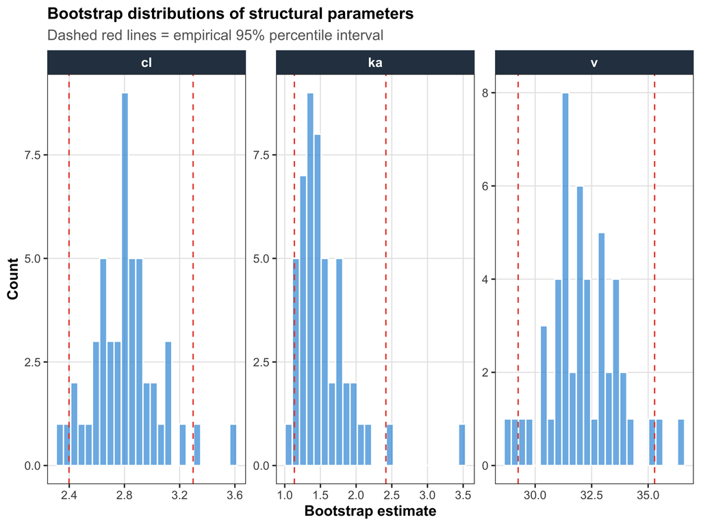

Bootstrap sampling distributions of CL, V, and Ka (dashed = 95% percentile interval).

```r
boot_plot(boot)
```

## 5 Key takeaways

- Parameter uncertainty was quantified **empirically** by subject resampling, free of the normality assumption behind asymptotic SEs.
- The bootstrap and asymptotic CIs can be compared directly; close agreement validates the reported precision, while divergence (typically for Ka) flags small-sample fragility.
- With n = 12 the bootstrap is itself coarse and presented as a **demonstration of method** — exactly how it would be framed for a small study.

> Next (Phase 11): a **covariate forest plot** summarising the weight effect on CL and V with confidence intervals. ```